# Systemy Decyzyjne 2023/2024

Laboratorium 5 - sieci neuronowe i SVM

Andrzej Janusz

## Konstrukcja perceptronu

W najprostrzej wersji perceptron jest modelem neuronu. Posiada $N$ wejść, jedno wyjście i funkcję aktywacji. Z każdym wejściem stowarzyszona jest pewna waga (najcześciej przyjmująca wartości z przedziału $[-1,1]$). Dodatkowo, często dodaje się jedną wagę nie związaną z żadnym wejściem (“bias factor”). Perceptron sumuje ważone sygnały wejściowe i na wyjściu zwraca wartość funkcji aktywacji od obliczonej sumy. Funkcje aktywacji mogą być różnego typu, lecz najczęściej używa się różniczkowalnych funkcji sigmoidalnych, np. funkcji logistycznej:
$$sigmoid(x) =
\frac{1}{(1 + e^{-x})}$$
lub tangensa hiperbolicznego:
$$tanh(x) = \frac{(e^x - e^{-x})}{(e^x +
e^{-x})}$$

```r
set.seed(16112023)

# Prosta reprezentacja neuronu:
createNeuron = function(nIn, activationF = e1071::sigmoid,
                        activationDer = e1071::dsigmoid, range = 0.1) {
  list(weights = runif(nIn + 1, -range, range),
       fun = activationF,
       derivative = activationDer)
}

neuron = createNeuron(2, range = 0.5)
neuron
```

```
$weights
[1]  0.01914874 -0.29389498  0.17275611

$fun
function (x)
1/(1 + exp(-x))
<bytecode: 0x0000023ca24ee4a0>
<environment: namespace:e1071>

$derivative
function (x)
sigmoid(x) * (1 - sigmoid(x))
<bytecode: 0x0000023ca24edcc0>
<environment: namespace:e1071>
```

Uczenie perceptronu - metoda gradientowa (dla funkcji straty - kwadratu błędu różnicy predykcji i ‘ground truth’). Polega ona na iteracyjnym uaktualnianiu wag zgodnie z kierunkiem spadku wartości funkcji błędu i proporcjonalnie do wielkości wejścia.

- $E = 0.5*(true - pred)^2$ - blad kwadratowy
- $deltaW(i) = alpha*(true - pred)*f'(W * X)*X_i$, gdzie
- $deltaW(i)$ - uaktualnienie i-tej wagi
- $W$ - wektor wag neuronu
- $X = <X_1, ..., X_N>$ - wejscie dla neuronu

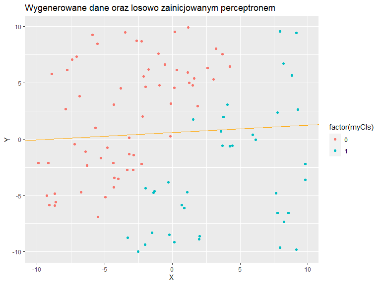

```r
# wygenerujmy losowy zbiorek danych 2D
myRandomData = matrix(runif(200, -10, 10), 100)
myCls = apply(myRandomData, 1,
              function(x) as.integer(c(7,-5)%*%x > 0))


# możemy pokazać, w jaki sposób nasz perceptron dzieli dane przed uczenie:
fig1 <- ggplot(data.table(myRandomData), aes(x=V1, y=V2, colour = factor(myCls))) +
  geom_point() +
  geom_abline(intercept = -neuron$weights[3]/neuron$weights[2],
              slope = -neuron$weights[1]/neuron$weights[2], colour = "orange") +
  labs(x = "X", y = "Y", title = "Wygenerowane dane oraz losowo zainicjowanym perceptronem")
fig1
```

```r
# implementacja prostej metody uczenia perceptronu:
weightedSum = function(input, neuron) {
  as.numeric(c(input,1) %*% neuron$weights)
}

compErr = function(input, target, neuron) {
  abs(target - neuron$fun(weightedSum(input, neuron)))
}

updateWeights = function(input, target, neuron, alpha = 0.1) {

  wSum = weightedSum(input, neuron)
  deltaW = -alpha*(target - neuron$fun(wSum))*neuron$derivative(wSum)*c(input,1)
  neuron$weights = neuron$weights - deltaW

  neuron
}
```

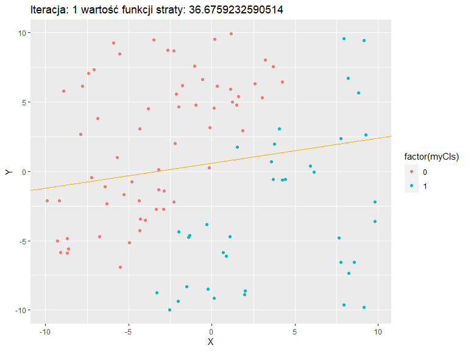

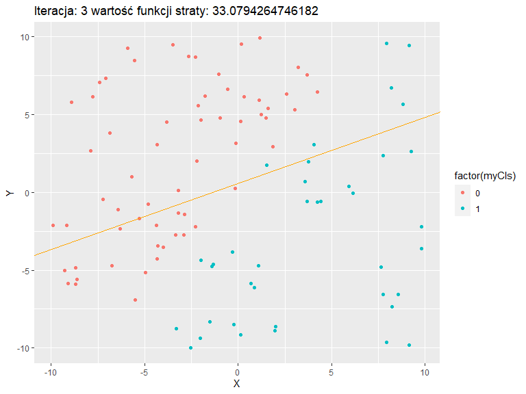

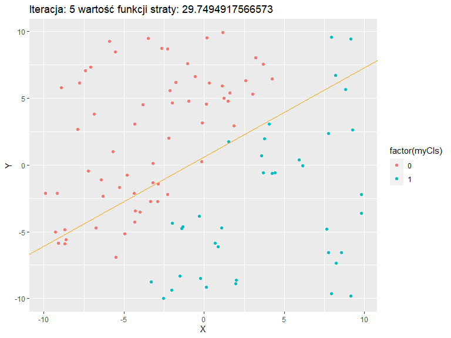

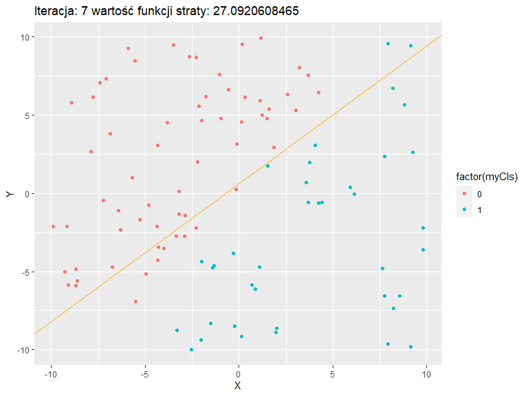

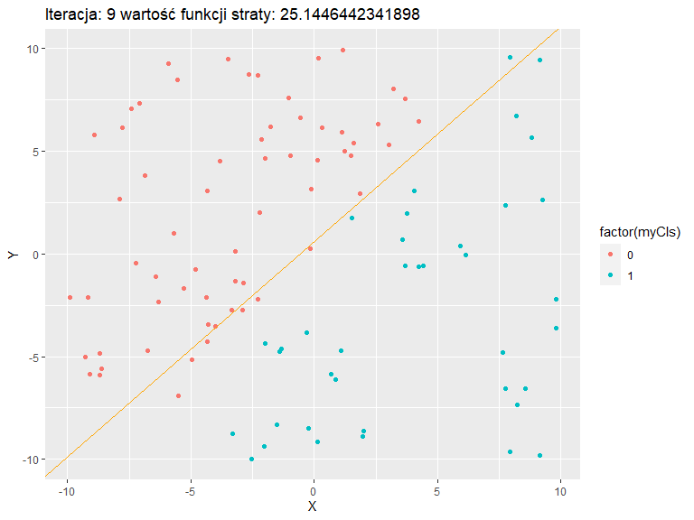

```r
# sprawdzmy czy uda nam sie wytrenowac perceptron
endFlag = FALSE
threshold = 0.1
maxIterations = 100
alpha = 0.001

iteration = 1
while(!endFlag) {
    errVec = mapply(compErr,
                    split(myRandomData, 1:nrow(myRandomData)), myCls,
                    MoreArgs = list(neuron = neuron))
    if(sum(errVec) < threshold || iteration > maxIterations) endFlag = T
    else {
        for(i in 1:nrow(myRandomData))
          neuron = updateWeights(myRandomData[i,], myCls[i], neuron, alpha)
        if(iteration <= 10 && iteration %% 2 == 1) {
          tmp_plot <- ggplot(data.table(myRandomData), aes(x=V1, y=V2, colour = factor(myCls))) +
                        geom_point() +
                        geom_abline(intercept = -neuron$weights[3]/neuron$weights[2],
                                    slope = -neuron$weights[1]/neuron$weights[2], colour = "orange") +
                        labs(x = "X", y = "Y", title = paste0("Iteracja: ", iteration, " wartość funkcji straty: ", sum(errVec)))
          print(tmp_plot)
        }
        iteration = iteration + 1
    }
}
```

```r
print(sum(errVec))
```

```
[1] 11.66276
```

```r
print(neuron)
```

```
$weights
[1]  0.60742504 -0.41596815  0.02474156

$fun
function (x)
1/(1 + exp(-x))
<bytecode: 0x0000023ca24ee4a0>
<environment: namespace:e1071>

$derivative
function (x)
sigmoid(x) * (1 - sigmoid(x))
<bytecode: 0x0000023ca24edcc0>
<environment: namespace:e1071>
```

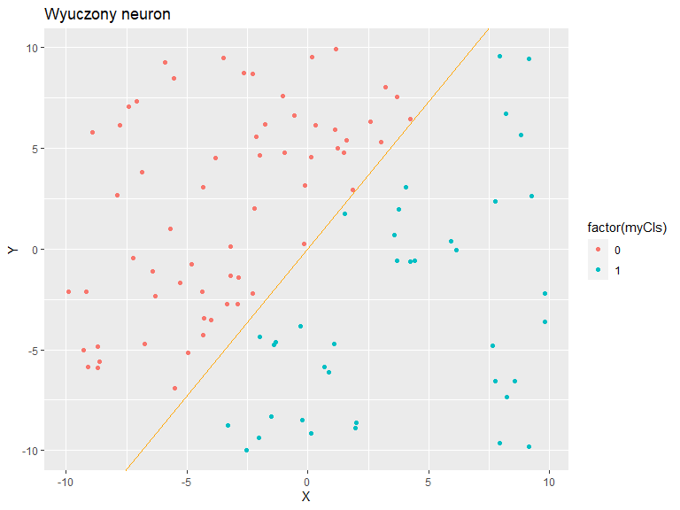

```r
# mozemy teraz narysowac nasz model
fig2 <- ggplot(data.table(myRandomData), aes(x=V1, y=V2, colour = factor(myCls))) +
  geom_point() +
  geom_abline(intercept = -neuron$weights[3]/neuron$weights[2],
              slope = -neuron$weights[1]/neuron$weights[2], colour = "orange") +
  labs(x = "X", y = "Y", title = "Wyuczony neuron")
fig2
```

## Proste sieci neuronowe

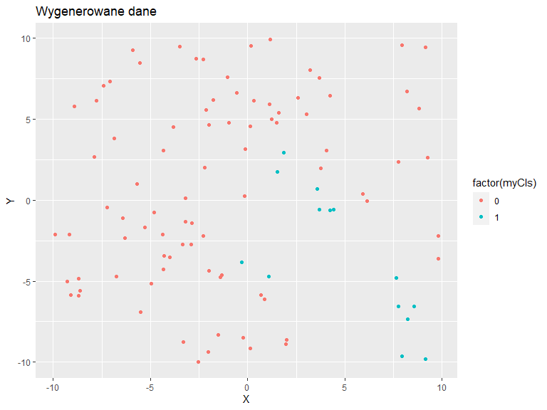

```r
# A co gdy decyzja jest bardziej złożona?
myCls = apply(myRandomData, 1, function(x) return(as.integer(c(3,-1)%*%x > 0 &
                                                             c(-1,-1)%*%x + 5 > 0 &
                                                             c(-1,-1)%*%x - 5 < 0)))


fig3 <- ggplot(data.table(myRandomData), aes(x=V1, y=V2, colour = factor(myCls))) +
  geom_point() +
  labs(x = "X", y = "Y", title = "Wygenerowane dane")
fig3
```

Żeby nauczyć sieć neuronową bardziej skomplikowanych “kształtow” klas decyzyjnych należy połączyć pojedyncze neurony w sieć. Najczęsciej stosowanym algorytmem trenowania sieci neuronowych jest metoda wstecznej propagacji błędu.

Algorytm:

1. Zainicjuj sieć (losowo).
2. Powtarzaj dla kolejnych obiektów/zbiorów (ang. batches) aż do osiągnięcia kryterium stopu:
   - oblicz błąd klasyfikacji obiektu,
   - oblicz uaktualnienia wag $deltaW(i)$ pomiędzy neuronem wyjściowym a i-tym neuronem ukrytym,
   - dla wszystkich neuronów w warstwie ukrytej oblicz uaktualnienia wag $deltaW(i,j)$ miedzy i-tym neuronem a j-tym wejsciem,
   - uaktualnij wszystkie wagi modelu.

Jaką strukturę powinna mieć sieć dla tak zadanej klasy decyzyjnej?

Odp: 2-3-1

```r
# Podstawowa implementacja (prostych) sici neuronowych w R:
#manual: ?nnet::nnet

# Mozemy zaprojektowac i wyuczyc siec neuronowa z nnet dla powyzszych danych.
tmpMyCls = myCls
tmpMyCls[tmpMyCls == 0] = -1


nnetModel = nnet(myRandomData, tmpMyCls,  size = 3,
                 linout = TRUE, maxit = 1000, abstol = 1.0e-6, trace = FALSE)
summary(nnetModel)
```

```
a 2-3-1 network with 13 weights
options were - linear output units
  b->h1  i1->h1  i2->h1
  -2.52   35.89   -6.17
  b->h2  i1->h2  i2->h2
 134.72  -25.23  -29.00
  b->h3  i1->h3  i2->h3
 217.31 -108.30  -66.34
   b->o   h1->o   h2->o   h3->o
  -1.20    0.28    1.94   -1.70
```

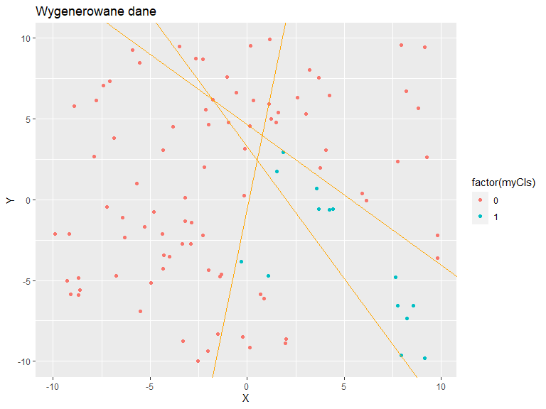

```r
fig4 <- ggplot(data.table(myRandomData), aes(x=V1, y=V2, colour = factor(myCls))) +
  geom_point() +
  geom_abline(intercept = -nnetModel$wts[1]/nnetModel$wts[3],
              slope = -nnetModel$wts[2]/nnetModel$wts[3], colour = "orange") +
  geom_abline(intercept = -nnetModel$wts[4]/nnetModel$wts[6],
              slope = -nnetModel$wts[5]/nnetModel$wts[6], colour = "orange") +
  geom_abline(intercept = -nnetModel$wts[7]/nnetModel$wts[9],
              slope = -nnetModel$wts[8]/nnetModel$wts[9], colour = "orange") +
  labs(x = "X", y = "Y", title = "Wygenerowane dane")
fig4
```

```r
# W celu predykcji etykiet dla nowych obiektow w nnet wykorzystuje sie metode predict.
```

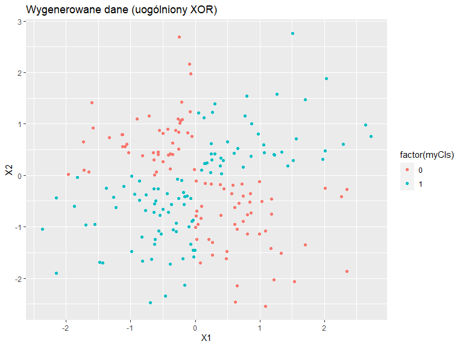

```r
set.seed(16112023)
# a jak to wygląda dla jeszcze bardziej skomplikowanych danych?
myRandomData <- matrix(rnorm(400), 200)
colnames(myRandomData) <- c("X1", "X2")
myCls = apply(myRandomData, 1, function(x) as.integer(all(x>0) | all(x<0)))

fig5 <- ggplot(data.table(myRandomData), aes(x=X1, y=X2, colour = factor(myCls))) +
  geom_point() +
  labs(x = "X1", y = "X2", title = "Wygenerowane dane (uogólniony XOR)")
fig5
```

```r
# Konstruowanie własnych sieci neuronowych o nieco bardziej skomplikowanej strukturze umożliwia biblioteka neuralnet
# Biblioteka nie jest idealna i zawiera błędy - ale korzystamy z niej jedynie w celu szkoleniowym ;-)
myDF <- data.frame(cbind(myRandomData, class = myCls))

myNNet <- neuralnet(class ~.,
                    data = myDF,
                    hidden = c(2, 2), rep = 3,
                    linear.output = FALSE,
                    threshold = 0.01,
                    stepmax = 1e+06,
                    lifesign = "minimal",
                    act.fct = "tanh",
                    err.fct = "sse")
```

```
hidden: 2, 2    thresh: 0.01    rep: 1/3    steps:    6506  error: 13.79066 time: 0.9 secs
hidden: 2, 2    thresh: 0.01    rep: 2/3    steps:    8901  error: 15.77187 time: 1.13 secs
hidden: 2, 2    thresh: 0.01    rep: 3/3    steps:    4076  error: 0.00449  time: 0.51 secs
```

```r
?neuralnet
myNNet$result.matrix
```

```
                               [,1]          [,2]          [,3]
error                  1.379066e+01   15.77187396  4.493178e-03
reached.threshold      9.985494e-03    0.00990467  9.683686e-03
steps                  6.506000e+03 8901.00000000  4.076000e+03
Intercept.to.1layhid1  9.410517e+00   -0.51639925 -1.131308e+00
X1.to.1layhid1        -1.016754e+02   -1.94827950 -8.823052e-02
X2.to.1layhid1        -6.094621e+00    2.97735389 -1.317922e+02
Intercept.to.1layhid2 -5.667390e-01    3.12409443 -2.961063e-01
X1.to.1layhid2        -6.390887e-01   -1.99544384 -1.944537e+02
X2.to.1layhid2        -7.473595e+01    1.90081942 -3.142272e-01
Intercept.to.2layhid1  2.916266e+00   -0.26482694  5.310263e+00
1layhid1.to.2layhid1  -8.100432e-01    2.53319043  6.404585e+00
1layhid2.to.2layhid1   2.947960e+00   -2.10540610  6.392826e+00
Intercept.to.2layhid2  2.367683e+00   -0.62945390 -9.107456e+00
1layhid1.to.2layhid2   1.079025e+00  -13.77005408  9.092062e+00
1layhid2.to.2layhid2   3.442510e+00  -13.66427664  1.038253e+01
Intercept.to.class     1.061509e+00   -0.18448065  2.677706e+00
2layhid1.to.class      1.533560e+00   -1.15147746 -1.323320e+00
2layhid2.to.class     -1.990017e+00   -0.53971270  1.354366e+00
```

```r
sum(abs(myNNet$net.result[[which.min(myNNet$result.matrix["error", ])]] - myCls))
```

```
[1] 0.96843
```

```r
mean(round(myNNet$net.result[[which.min(myNNet$result.matrix["error", ])]]) == myCls)
```

```
[1] 1
```

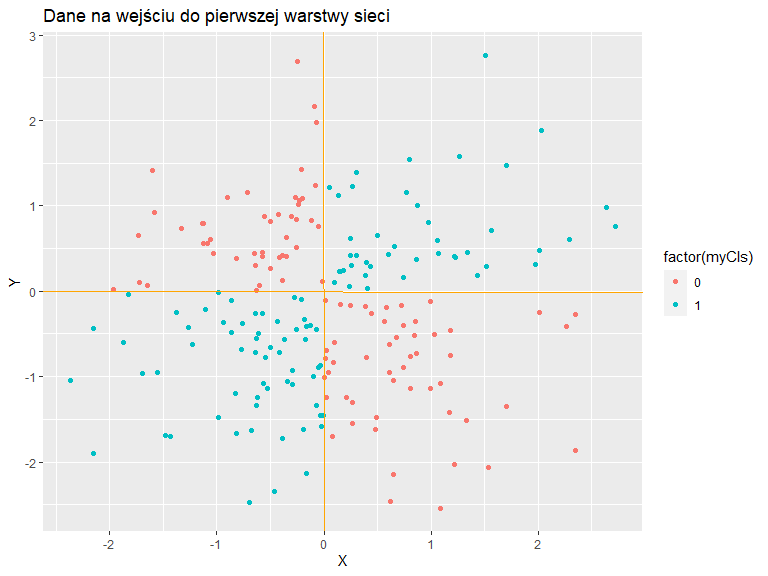

```r
# jak wyglada pierwsza warstwa?
fig6 <- ggplot(data.table(myRandomData), aes(x=X1, y=X2, colour = factor(myCls))) +
  geom_point()

model_weights <- myNNet$result.matrix[, which.min(myNNet$result.matrix["error", ])]

fig6 <- fig6 + geom_abline(intercept = -model_weights["Intercept.to.1layhid1"]/model_weights["X2.to.1layhid1"],
              slope = -model_weights["X1.to.1layhid1"]/model_weights["X2.to.1layhid1"], colour = "orange")
fig6 <- fig6 + geom_abline(intercept = -model_weights["Intercept.to.1layhid2"]/model_weights["X2.to.1layhid2"],
              slope = -model_weights["X1.to.1layhid2"]/model_weights["X2.to.1layhid2"], colour = "orange")
fig6 <- fig6 + labs(x = "X", y = "Y", title = "Dane na wejściu do pierwszej warstwy sieci")
fig6
```

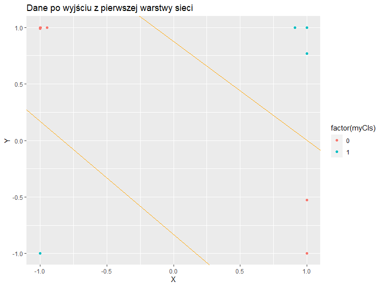

```r
# jak wygladają dane po wyjściu z pierwszej warstwy neuronów?
transformX <- function(x, weights, bias) {
  tanh(x%*%weights + bias)
}

transformedData = apply(myRandomData, 1,
                        function(x) c(transformX(x, model_weights[c("X1.to.1layhid1", "X2.to.1layhid1")],
                                                 model_weights["Intercept.to.1layhid1"]),
                                      transformX(x, model_weights[c("X1.to.1layhid2", "X2.to.1layhid2")],
                                                 model_weights["Intercept.to.1layhid2"])))
transformedData = t(transformedData)

# narysujmy dane i neurony z drugiej warstwy
fig7 <- ggplot(data.table(transformedData), aes(x=V1, y=V2, colour = factor(myCls))) +
  geom_point()


fig7 <- fig7 + geom_abline(intercept = -model_weights["Intercept.to.2layhid1"]/model_weights["1layhid2.to.2layhid1"],
              slope = -model_weights["1layhid1.to.2layhid1"]/model_weights["1layhid2.to.2layhid1"], colour = "orange")
fig7 <- fig7 + geom_abline(intercept = -model_weights["Intercept.to.2layhid2"]/model_weights["1layhid2.to.2layhid2"],
              slope = -model_weights["1layhid1.to.2layhid2"]/model_weights["1layhid2.to.2layhid2"], colour = "orange")
fig7 <- fig7 + labs(x = "X", y = "Y", title = "Dane po wyjściu z pierwszej warstwy sieci")
fig7
```

```r
# Co tu się stało?
```

## Margin classifier (definicja modelu SVM)

[figure not shown]

```r
# wygenerujmy sobie ponownie jakieś proste dane
#hejka
myRandomData = matrix(runif(60, -1, 1), 30)
myCls = apply(myRandomData, 1, function(x) return(as.integer(c(-7,3)%*%x > 0)))
myRandomData[myCls == 0, ] = myRandomData[myCls == 0, ] + 0.3

fig8 <- ggplot(data.table(myRandomData), aes(x=V1, y=V2, colour = factor(myCls))) +
  geom_point() +
  labs(x = "X", y = "Y", title = "Wygenerowane proste dane")
fig8
```

```r
# funkcja uczaca perceptron
trainNeuron = function(neuron, dataTab, clsVec,
                       alpha = 0.1, maxIterations = 100,
                       threshold = 0.025, printInfo = TRUE) {

  endFlag = FALSE
  iteration = 1
  prevErrs = Inf
  while(!endFlag) {
    errVec = mapply(compErr,
                    split(dataTab, 1:nrow(dataTab)), as.list(clsVec),
                    MoreArgs = list(neuron = neuron))
    errSum = sum(errVec)
    if(prevErrs - errSum < threshold || iteration > maxIterations) {
      endFlag = TRUE
    } else {
      for(i in 1:nrow(dataTab))
        neuron = updateWeights(dataTab[i,], clsVec[i], neuron, alpha)
      if(printInfo && iteration %% 10 == 1) {
        cat("Iteracja: ", iteration, " suma bledow: ", errSum, "\n", sep="")
      }
      prevErrs = errSum
      iteration = iteration + 1
    }
  }
  if(printInfo) {
    print(sum(errVec))
    print(neuron)
  }
  neuron
}
```

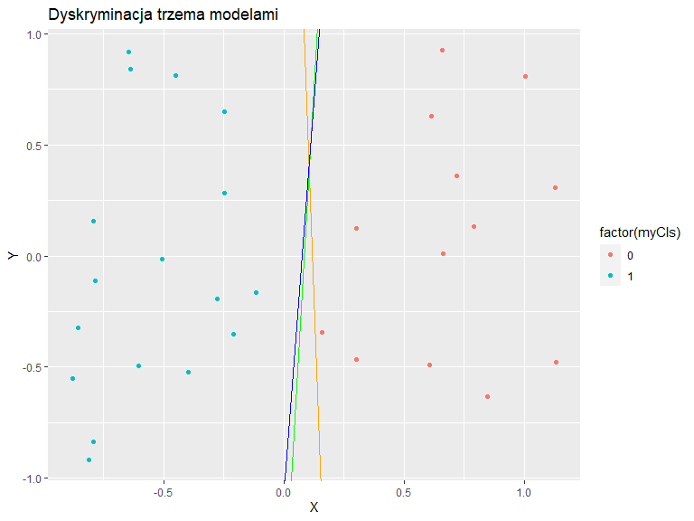

```r
# stworzmy trzy perceptrony uczone z różnymi parametrami
neuron = list(neuron1 = createNeuron(2, range = 0.2),
              neuron2 = createNeuron(2, range = 0.2),
              neuron3 = createNeuron(2, range = 0.2))

alpha = c(0.1,0.5,0.9)

neuron = mapply(function(perceptron, alpha, dataT, cls, maxIt, info)
                           trainNeuron(perceptron, dataT, cls, alpha, maxIt, printInfo = info),
                neuron, alpha,
                MoreArgs = list(dataT = myRandomData, cls = myCls, maxIt = 20, info = FALSE),
                SIMPLIFY = FALSE)

# w wyniku uczenia dostajemy trzy hiperplaszczyzny:
fig9 <- ggplot(data.table(myRandomData), aes(x=V1, y=V2, colour = factor(myCls))) +
  geom_point() +
  geom_abline(intercept = -neuron[[1]]$weights[3]/neuron[[1]]$weights[2],
              slope = -neuron[[1]]$weights[1]/neuron[[1]]$weights[2], colour = "orange") +
  geom_abline(intercept = -neuron[[2]]$weights[3]/neuron[[2]]$weights[2],
              slope = -neuron[[2]]$weights[1]/neuron[[2]]$weights[2], colour = "green") +
  geom_abline(intercept = -neuron[[3]]$weights[3]/neuron[[3]]$weights[2],
              slope = -neuron[[3]]$weights[1]/neuron[[3]]$weights[2], colour = "blue") +
  labs(x = "X", y = "Y", title = "Dyskryminacja trzema modelami")
fig9
```

```r
# który z powyższych modeli jest najlepszy???
```

Możemy przyjąć, że najbardziej stabilny klasyfikator będzie odpowiadał hiperpłaszczyznie, która dobrze rozróżnia punkty z różnych klas decyzyjnych i jest od tych punktów jak najbardziej oddalona.

[figure not shown]

Wizualizacja modelu SVM (obrazek wykonany przez Larhmam - Own work, CC BY-SA 4.0, https://commons.wikimedia.org/w/index.php?curid=73710028)

Zdefiniujmy zatem zadanie optymalizacyjne:

- $u_1, \ldots, u_n$ - obiekty treningowe,
- $d_1, \ldots, d_n$ - binarna klasyfikacja obiektów treningowych taka, że $d_i \in {-1,1}$,
- $u_i * u_j$ - iloczyn skalarny (klasyczny) $u_i$ i $u_j$,
- $w * u - b = 0$ - równanie hiperplaszczyzny, gdzie $w$ to wektor współczynników (wag).

Chcemy maksymalizować odległość między hiperpłaszczyznami $w * u - b = 1$ i $w * u - b = -1$ tak, żeby były spełnione warunki:

- $w * u_i - b \geq 1$ dla $u_i$ takich, że $d_i = 1$,
- $w * u_i - b \leq -1$ dla $u_i$ takich, że $d_i = -1$,

czyli mamy warunek $d_i (w * u_i - b) >= 1$ dla $i = 1, \ldots, n$.

Odległość pomiędzy tymi dwiema hiperpłaszczyznami wynosi $\frac{2}{||w||}$, czyli chcemy minimalizowac normę wektora $w$.

Dzięki wykorzystaniu metody mnożników Lagrange-a otrzymujemy rozwiązanie:
$$w = \sum_{i}( \alpha_i * d_i *
u_i),$$
gdzie $\alpha_i$ odpowiadają maksimum z funkcji Lagrange-a:
$$L(\alpha) = \sum_{i}( \alpha_i ) -
1/2*\sum_{i,j}\left[ \alpha_i * \alpha_j * d_i * d_j * ( K(u_i, u_j) )
\right],$$
z warunkami brzegowymi $\alpha_i \geq 0$ dla $i = 1, \ldots, n$ oraz $\sum_{i}( d_i*\alpha_i ) = 0$.

W powyższym wzorze $K(u_i, u_j)$ jest funkcja jądrowa (ang. *kernel function*) zdefiniowaną jako $K(u_i, u_j) = u_1 * u_2$ (zwykły iloczyn skalarny). Tak zdefiniowany model nazywamy *maszyną wektorów wspierających* (ang. *support vector machine*).

```r
# ten sam model możecie wytrenować wykorzystując pakiet mlr3! (learner classif.svm)
#manual:  ?e1071::svm

svmModel = svm(myRandomData, myCls,
               scale = FALSE, type = "C-classification", kernel = "linear",
               cost = 1000)
# możemy również używać interfejsu przez formułę a dane moga mieć 'rzadką' reprezentację

names(svmModel)
```

```
 [1] "call"            "type"            "kernel"          "cost"            "degree"          "gamma"
 [7] "coef0"           "nu"              "epsilon"         "sparse"          "scaled"          "x.scale"
[13] "y.scale"         "nclasses"        "levels"          "tot.nSV"         "nSV"             "labels"
[19] "SV"              "index"           "rho"             "compprob"        "probA"           "probB"
[25] "sigma"           "coefs"           "na.action"       "fitted"          "decision.values"
```

```r
svmModel$coefs  #czyli nasze wartości alpha_i (już pomnożone przez d_i)
```

```
           [,1]
[1,]  20.010297
[2,]  -3.766915
[3,] -16.243382
```

```r
svmModel$rho    #czyli nasze przesunięcie 'b'
```

```
[1] -0.6009584
```

```r
svmModel$index  #indeksy wektorów wspierających w naszych danych
```

```
[1] 13  5  8
```

```r
svmModel$SV     #macierz wektorów wspierających
```

```
           X1         X2
13 -0.1158543 -0.1639513
5   0.3020386  0.1233517
8   0.1598467 -0.3439950
```

```r
# suma współczynników powinna wynosić zero:
cat('Suma wspolczynnikow: ',
    round(sum(svmModel$coefs), 10), '\n')
```

```
Suma wspolczynnikow:  0
```

```r
# Narysujmy teraz wyuczona hiperplaszczyzne:
w = apply((svmModel$SV) * as.numeric(svmModel$coefs),2,sum)

fig10 <- ggplot(data.table(myRandomData), aes(x=V1, y=V2, colour = factor(myCls))) +
  geom_point() +
  geom_abline(intercept = svmModel$rho/w[2],
              slope = -w[1]/w[2], colour = "Blue") +
  geom_abline(intercept = (svmModel$rho+1)/w[2],
              slope = -w[1]/w[2], colour = "Red", size = 1) +
  geom_abline(intercept = (svmModel$rho-1)/w[2],
              slope = -w[1]/w[2], colour = "Red", size = 1) +
  labs(x = "X", y = "Y", title = "Dyskryminacja modelem SVM")
```

```
Ostrzeżenie: Using `size` aesthetic for lines was deprecated in ggplot2 3.4.0.
Please use `linewidth` instead.
```

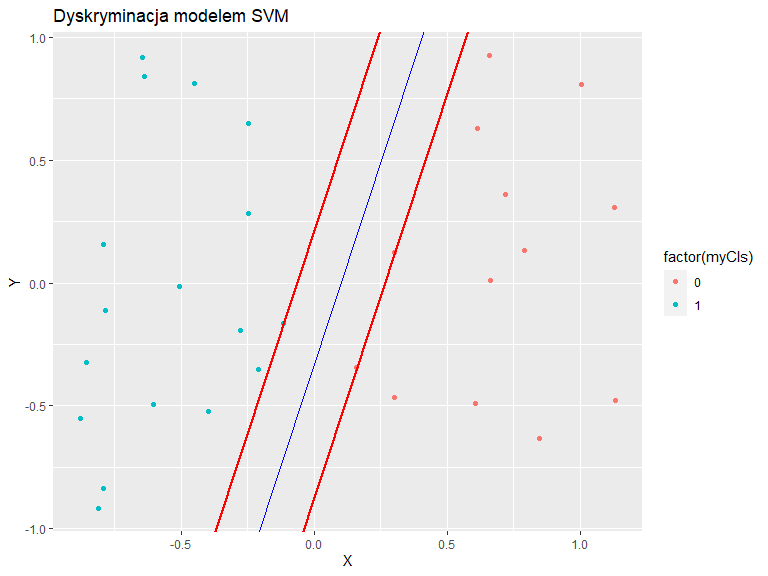

```r
fig10
```

Warto zauważyć, że nasze hiperpłaszczyzny dyskryminujące mogą *opierać się* jedynie na niewielkiej liczbie obiektów z naszych danych - jedynie dla nich odpowiadające wartości $alpha_i$ są niezerowe. Obiekty te nazywamy wektorami wspierającymi/podpierającymi.

A co w sytuacji, gdy kilku obiektów nie da sie liniowo przypisać do prawidłowej klasy?

Modyfikujemy problem optymalizacji przez wprowadzenie dodatkowych zmiennych odpowiadających karze za nieprawidłową klasyfikację. Chcemy teraz minimalizować
$$Loss(w, C) = ||w|| +
C*\sum_{i}( \epsilon_i ),$$
gdzie $\epsilon_i$ to kara za klasyfikację i-tego obiektu, a $C$ to stała. W 1995 roku Vapnik pokazał, że rozwiązanie Lagrange-a tego problemu pozostaje prawie niezmienione.

Wystarczy tylko dodać warunek: $alpha_i \leq C$ dla $i = 1, \ldots, n$. W implementacji z biblioteki *e1071* stałej $C$ odpowiada parametr *cost*.

## Klasyfikacja nieliniowa modelem SVM (kernel trick):

Do tej pory zakładaliśmy, że funkcja $K(u_i, u_j)$ jest zwykłym iloczynem skalarnym. A co jeśli założymy, że funkcja ta jest iloczynem skalarnym w innej przestrzeni, niż ta odpowiadająca wymiarom w naszych danych?

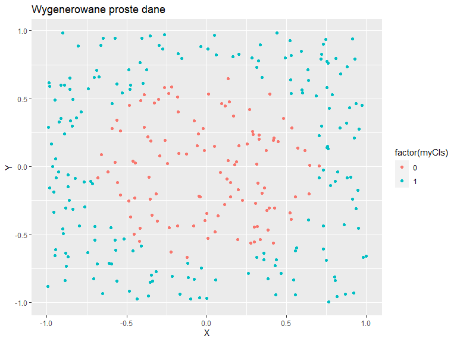

```r
# Ponownie wygenerujmy nowe dane
myRandomData = matrix(runif(600, -1, 1), 300)
myCls = apply(myRandomData, 1, function(x) return(as.integer(sum(x^2) > 0.5)))

fig11 <- ggplot(data.table(myRandomData), aes(x=V1, y=V2, colour = factor(myCls))) +
  geom_point() +
  labs(x = "X", y = "Y", title = "Wygenerowane proste dane")
fig11
```

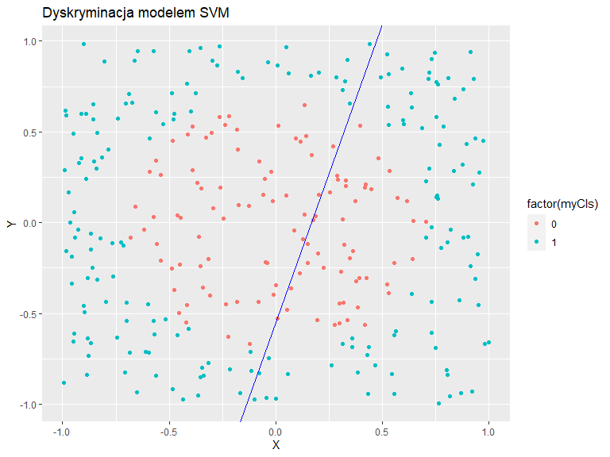

```r
# Takich danych nie da się sensownie podzielić hiperpłaszczyzną w dwóch wymiarach...
svmModel = svm(myCls~., as.data.frame(cbind(myRandomData, myCls)),
               type = "C-classification", kernel = "linear", cost = 1, scale = FALSE)

fig12 <- ggplot(data.table(myRandomData), aes(x=V1, y=V2, colour = factor(myCls))) +
  geom_point() +
  geom_abline(intercept = svmModel$rho/w[2],
              slope = -w[1]/w[2], colour = "Blue") +
  labs(x = "X", y = "Y", title = "Dyskryminacja modelem SVM")
fig12
```

```r
# Konieczna jest zatem transformacja obiektów do przestrzeni o większym wymiarze.
# Proszę spróbować samodzielnie zgadnąć jaka transformacja byłaby odpowiednia.
# Proszę sprawdzić swoje rozwiązanie wyliczając SVM na nowych (przetransformowanych) danych.
```

W praktyce nie jest konieczne realizowanie (materializacja) takiej transformacji - do budowy modelu *SVM* potrzebujemy jedynie wartosci iloczynu skalarnego w przestrzeni **po transformacji**. Możemy zatem wykorzystać tzw. *“kernel trick”*. Funkcję $K(u_i, u_j)$ dobierzemy tak, by odpowiadała iloczynowi skalarnemu w nowej przestrzeni. Dzięki temu możemy w znaczący sposób obniżyć złożoność obliczeniową problemu optymalizacji.

Trzy najczęściej wykorzystywane funkcje jądrowe to: *liniowa*, *wielomianowa* i *radialna* (sigmoidalna).

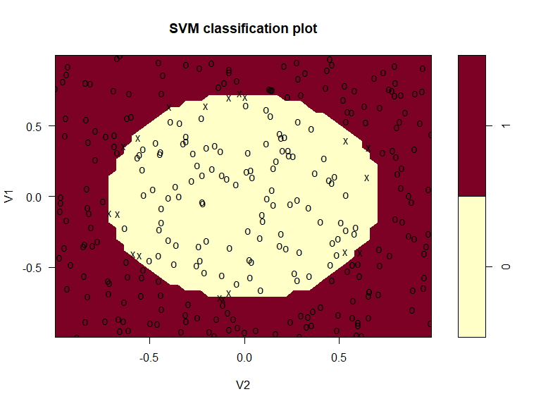

```r
# policzmy SVM z jądrem radialnym
svmModel = svm(myCls~., as.data.frame(cbind(myRandomData,myCls)),
               type = "C-classification", kernel = "radial", cost = 100)

# narysujmy model (uzyjemy metody plot)
plot(svmModel, as.data.frame(cbind(myRandomData,myCls)))
```

### Zadanie na następne zajęcia (laboratoria):

Proszę o zainstalowanie bibliotek **tensorflow** oraz **keras** https://tensorflow.rstudio.com/installation/

```r
#library(tensorflow)
tf$constant("Hello TensorFlow!")
```

```
tf.Tensor(b'Hello TensorFlow!', shape=(), dtype=string)
```